# Kapittel 3: Bruk av Julia

### 3.2.5 Enkel plotting i 2D

`Makie.jl` har flere funksjoner for å plotte data i 2D, noen av de har vi vist tidligere. Her kopierer vi eksempelet fra boken, og fra Python-oversettelsen:

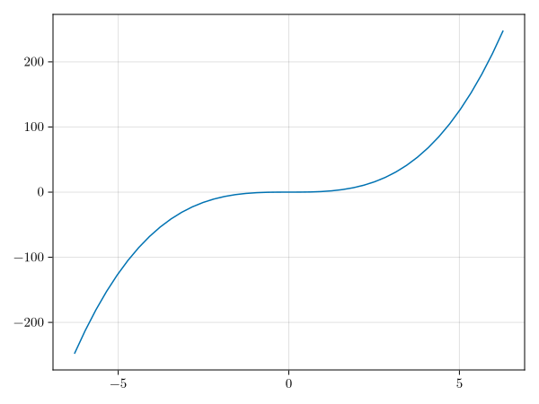

```julia
x = LinRange(-2π, 2π, 41)
y = x .^ 3
lines(x, y)
```

Vi kan også plotte funksjoner som er gitt ved en parametrisering. En sirkel med radius r kan uttrykkes med $x(t) = r \cos(t)$ og $y(t) = r \sin(t)$, der $t$ går fra 0 til $2\pi$. Vi plotter en sirkel med radius 3:

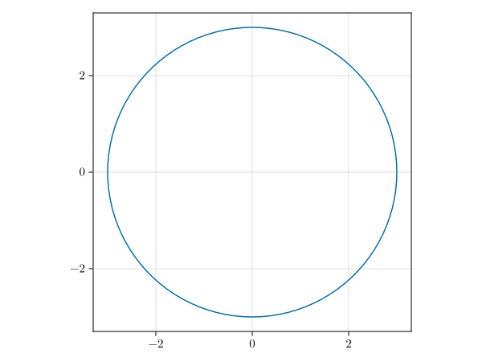

```julia
t = LinRange(0, 2π, 101)
x = 3 * cos.(t)
y = 3 * sin.(t)
fig = Figure()
ax = Axis(fig[1, 1], aspect = DataAspect())
lines!(ax, x, y)
fig
```

### 3.2.6 Punktum foran en operasjon

Noen tegn/operasjoner (f.eks. `*`, `/`, og `^`) brukes til to forskjellige matematiske funksjoner. Når variablene disse operasjonene virker på er skalarer, vil den vanlige betydning (multiplikasjon og divisjon) gjelde slik at f.eks `3*2`vil gi det forventede svaret `6`. Hvis variablene derimot er enten vektorer eller matriser, vil operasjonene betegne de tilsvarende matriseoperasjonene. Lar vi `A`og `B` være to matriser, vil `A*B` være matrisemultiplikasjon av `A` og `B`:

```julia
A = [1 2; 3 4]
B = [5 6; 7 8]
A * B
```

```
2×2 Matrix{Int64}:
 19  22
 43  50
```

Ønsker vi derimot at hvert element i `A` skal multipliseres med det tilsvarende elementet i `B`, bruker vi broadcasting-operatoren `.` foran operasjonen, som vi var inne på i Seksjon 3.2.1.3 Numerikk:

```julia
A .* B
```

```
2×2 Matrix{Int64}:
  5  12
 21  32
```

I eksempelet over der vi ønsket å regne ut $y=x^3$ og vi allerede har definert en vektor med $x$-verdier, vil vi at hvert element i $x$ skal opphøyes i tredje; vi ønsker *ikke* å bruke matrisemultiplikasjon av $x$ med seg selv to ganger. Merk at dersom du ønsker å multiplisere eller dividere en vektor eller en matrise med en skalar, behøver man ikke bruke broadcasting-operatoren `.` foran operasjonen. Her følger noen eksempler:

```julia
A .*2
```

```
2×2 Matrix{Int64}:
 2  4
 6  8
```

```julia
A * 2
```

```
2×2 Matrix{Int64}:
 2  4
 6  8
```

```julia
a = collect(1:4)
println(a)
println(a .* 2)
println(a * 2)
try
    a * a
catch e
    io = IOBuffer()
    showerror(io, e)
    error_msg = String(take!(io))
    @warn "Det fungerer ikke å gange en kolonnevektor med seg selv:\n$(error_msg)"
end
@info "Vi kan gange en radvektor (a') med en kolonnevektor (a):"
@show a' * a
```

```
[1, 2, 3, 4]
[2, 4, 6, 8]
[2, 4, 6, 8]
┌ Warning: Det fungerer ikke å gange en kolonnevektor med seg selv:
│ MethodError: no method matching *(::Vector{Int64}, ::Vector{Int64})
│ The function `*` exists, but no method is defined for this combination of argument types.
│
│ Closest candidates are:
│   *(::Any, ::Any, !Matched::Any, !Matched::Any...)
│    @ Base operators.jl:642
│   *(!Matched::ChainRulesCore.NotImplemented, ::Any)
│    @ ChainRulesCore ~/.julia/packages/ChainRulesCore/Vsbj9/src/tangent_arithmetic.jl:37
│   *(!Matched::ChainRulesCore.NoTangent, ::Any)
│    @ ChainRulesCore ~/.julia/packages/ChainRulesCore/Vsbj9/src/tangent_arithmetic.jl:64
│   ...
└ @ Main.Notebook ~/Code/JuliaMEK1100/kapittel3.qmd:514
[ Info: Vi kan gange en radvektor (a') med en kolonnevektor (a):
a' * a = 30
```

```
30
```

Her brukte vi flere nye funksjoner, men frykt ikke! Hjelpemodusen er din venn!

```julia
try
    a^2
catch e
    io = IOBuffer()
    showerror(io, e)
    error_msg = String(take!(io))
    @warn "Det fungerer ikke å opphøye en kolonnevektor i andre (samme som å gange med seg selv):\n$(error_msg)"
end
```

```
┌ Warning: Det fungerer ikke å opphøye en kolonnevektor i andre (samme som å gange med seg selv):
│ MethodError: no method matching ^(::Vector{Int64}, ::Int64)
│ The function `^` exists, but no method is defined for this combination of argument types.
│
│ Closest candidates are:
│   ^(!Matched::Regex, ::Integer)
│    @ Base regex.jl:913
│   ^(!Matched::Float64, ::Integer)
│    @ Base math.jl:1197
│   ^(!Matched::Irrational{:ℯ}, ::Integer)
│    @ Base mathconstants.jl:139
│   ...
└ @ Main.Notebook ~/Code/JuliaMEK1100/kapittel3.qmd:530
```

Broadcasting kan også brukes på vilkårlige funksjoner som er definert for en enkelt type, men i situasjoner der man vil anvende funksjoner elementvis på en vektorer av den typen. I det følgende eksempelet bruker vi funksjonen `reverse` elementvis på en vektor med strenger:

```julia
@show reverse("akebakke")
ordliste = ["eple", "tastatur", "støvsuger"]
reverse.(ordliste)
```

```
reverse("akebakke") = "ekkabeka"
```

```
3-element Vector{String}:
 "elpe"
 "rutatsat"
 "regusvøts"
```

## 3.3 Plotting av flater

Vi skal nå se på hvordan vi kan lage plottet av flaten i figur 1.7 (og 3.1) i boken. Dette er den samme flaten som vi har studert på side 18 i kapittel 1 og er gitt matematisk ved formelen
$$h = \frac{h_0}{1 + \frac{x^2 + y^2}{R^2}}
\tag{1.1}$$

Formelen modellerer en isolert fjelltopp der $h$ er høyden over havflaten, $h_0$ er høyden på toppen av fjellet, og $R$ er et mål for radius i fjellet. Konstantene $h_0$ og $R$ er satt til $2277$m og $4000$m.

Det kan være lurt å de påfølgende kommandoene i en REPL (eller linje for linje i en jl-fil) for å få en bedre oversikt over hva som skjer.

[figure not shown]

En modell av fjelltoppen Beerenberg på Jan Mayen

Før vi starter, importerer vi pakkene vi trenger. Siden vi skal lage et 3D-plot, bruker vi `GLMakie.jl`. For å spesifisere samme farger som i boken, bruker vi `Colors.jl`.

```julia
using GLMakie
using Colors
```

Først definerer vi konstantene våre $h_0$ og $R$. Vi definerer også en konstant for å konvertere kilometer til meter.

```julia
h0 = 2277
R = 4000
km = 1000
```

Nå definerer vi høyde-funksjonen $h(x, y)$.

```julia
h(x, y) = h0 / (1 + (x^2 + y^2) / R^2)
```

$x$- og $y$-aksen skal spenne over et område på $20\times 20$ km med sentrum i origo. I motsetning til i Matlab og Python, trenger vi ikke å lage et “meshgrid”, vi trenger bare $x$-verdiene og $y$-verdiene til punktene våre. Vi definerer konstanter for antallet punkter i $x$- og $y$-retningen, og lager vektorer for $x$- og $y$-verdiene.

```julia
nx = 41
ny = 41
x = LinRange(-10km, 10km, nx)
y = LinRange(-10km, 10km, ny)
```

Antallet punkter i hver retning må tilpasses for hvert eksempel, her har vi brukt 41 punkter i hver retning, som er passelig for å unngå at flaten blir for hakkete.

Vi lager en matrise med høydene for alle kobinasjoner av $x$- og $y$-verdiene.

```julia
z = h.(x, y')
```

[output not shown]

For å oppnå nøyaktig samme farger som i boken, lager vi en matrise med farger for hvert punkt. Her blir `color_matrix` en matrise med `nx` rader og `ny` kolonner, der hvert element er `custom_blue`-fargen.

```julia
custom_blue = RGB(0.35, 0.67, 0.93)
color_matrix = fill(custom_blue, nx, ny)
```

Vi lager en figur og plasserer en 3D-akse i figuren.

```julia
fig = Figure()
ax = Axis3(fig[1, 1], xlabel="x [km]", ylabel="y [km]", zlabel="h [m]")
```

Nå er vi klare for å plotte flaten! Her trenger vi to typer plotter: `surface` for å plotte flaten, og `wireframe` for å plotte rutenettet.

```julia
surface!(ax, x ./ km, y ./ km, z, color=color_matrix)
wireframe!(ax, x ./ km, y ./ km, z, color=:black)
fig
```

Her har vi brukt `./`-operatoren for å dele hvert element i `x` og `y` med `km` for å konvertere til kilometer.

## 3.4 Plotting av konturlinjer

Vi skal ta for oss et nytt eksempel fra kapittel 1, side 10; lufttrykket ved havoverflaten i tilknytning til et stormsenter. Formelen vi skal bruke er gitt ved

$$p = p_0 - \frac{\Delta p}{1 + \frac{x^2 + y^2}{R^2}}
\tag{1.2}$$

der $p_0$ er lufttrykket langt borte fra sentrum, $\Delta p$ er trykkfallet inn mot sentrum og $R$ er et mål for utstrekningen av lavtrykker. Konturlinjene vi skal plotte er gjengitt i Figur 1.1.

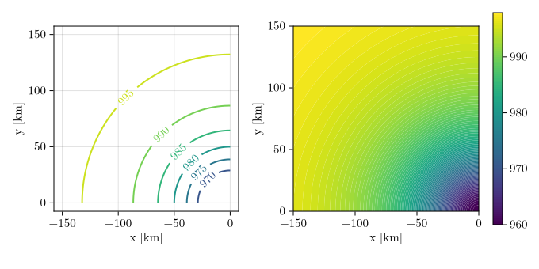

Figur 1.1: Til venstre: konturlinjer for konstant trykk (isobarer) rundt et lavtrykkssentrum. Til høyre: kontinuerlige farger for trykk.

Vi starter med konstantene som skal oppgis i km ($R$) og hPa ($p_0$ og $\Delta p$).

```julia
R = 50
p0 = 1000
dp = 40
```

Vi lager en funksjon for trykket $p(x, y)$.

```julia
p(x, y) = p0 - dp / (1 + (x^2 + y^2) / R^2)
```

Til forskjell fra boka skal vi her la $x$-aksen være definert over et område fra -150 til 0 km, og $y$-aksen være definert over et område fra 0 til 150 km, deretter regner vi ut p-verdiene for alle kobinasjoner av $x$- og $y$-verdiene.

```julia
x = LinRange(-150, 0, 151)
y = LinRange(0, 150, 151)
p_values = p.(x, y')
```

Vi lager en figur og plasserer en 2D-akse i figuren.

```julia
fig = Figure()
ax_contour = Axis(fig[1,1], xlabel="x [km]", ylabel="y [km]", aspect=DataAspect())
```

Nå plotter vi konturer med funksjonen `contour!`.

```julia
contour!(ax_contour, x, y, p_values, levels=[970, 975, 980, 985, 990, 995],
  labels=true, linewidth=2, labelsize=15
)
```

Her har vi spesifisert at vi vil ha konturlinjer for trykkene 970, 975, 980, 985, 990 og 995 hPa. Vi har også spesifisert at vi vil ha “labels” (tekst på konturlinjene). Hvis vi vil ha andre farger kan vi bruke argumentet `colormap`. F.eks. `colormap=:plasma`, eller `colormap=:jet` (`:jet` er samme colormap som i Python-oversettelsen). For en liste over alle tilgjengelige colormaps, se [Makie.jl colormaps](https://docs.makie.org/dev/explanations/colors#Colormaps).

Nå vil vi lage plottet til høyre i Figur 1.1. Her bruker vi funksjonen `contourf!` for å fylle inn flatene mellom konturlinjene. Først lager vi en ny akse og plasserer den i figuren.

```julia
ax_contourf = Axis(fig[1,2], xlabel="x [km]", ylabel="y [km]", aspect=DataAspect())
```

Så plotter vi fyltene med funksjonen `contourf!`.

```julia
cf = contourf!(ax_contourf, x, y, p_values, colormap=cmap, levels=100)
```

Her har vi spesifisert at vi vil ha 100 forskjellige konturnivåer. For å legge til en fargebar, bruker vi funksjonen `Colorbar`. Vi lagrer også plotteobjektet i variabelen `cf` for å kunne bruke det i funksjonen `Colorbar`.

```julia
Colorbar(fig[1,3], cf)
fig
```

Her har vi plassert fargebaren i figuren, og vi har brukt `fig[1,3]` for å plassere den til høyre for aksene. Når vi plasserer akser, fargebarer, og andre ting i figurer, kan vi bruke indeksering som ligner på matrise-indeksering. F.eks. `fig[1,3]` betyr plassering i rad 1, kolonne 3 i figuren.

## 3.5 Plotting av vektorfelt og beregning av gradientvektor

En vektor i kartesiske koordinater $\mathbf v = v_x(x,y)\mathbf i + v_y(x,y)\mathbf j$ kan plottes med funksjonen [arrows2d](https://docs.makie.org/dev/reference/plots/arrows).

`arrows2d` kan brukes på flere måter (ta gjerne en kikk på dokumentasjonen). Her bruker vi den enkleste. Da trenger vi å spesifisere punkter (gitt ved x og y-vektorer), og en funksjon som for ethvert punkt returnerer en vektor (gitt ved en x og y-komponent).

La oss ta et eksempel:
$$\mathbf v = (x^2 + 2y - \frac{1}{2}xy)\mathbf i - 3y\mathbf j$$

Vi lar $x$ og $y$ variere mellom $-5$ og $5$. Vi passer på å bruke større avstand mellom punktene for at vektorene ikke skal overlappe hverandre.

```julia
x = LinRange(-5, 5, 11)
y = LinRange(-5, 5, 11)
```

```
11-element LinRange{Float64, Int64}:
 -5.0, -4.0, -3.0, -2.0, -1.0, 0.0, 1.0, 2.0, 3.0, 4.0, 5.0
```

Så definerer vi vektorfeltet.

```julia
function v(point)
    x = point[1]
    y = point[2]
    return [(x^2 + 2y - 0.5x*y), -3y]
end
```

```
v (generic function with 1 method)
```

Nå kan vi plotte vektorfeltet.

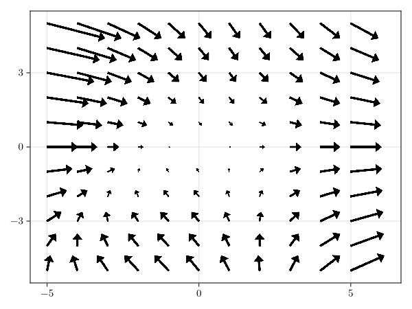

```julia
arrows2d(x, y, v, lengthscale=0.04)
```

Her har vi skalert ned vektorene for at de ikke skal overlappe hverandre.

Nå skal vi plotte gradientvektorer. Hvis vi har definert en en funksjon som er et skalarfelt i Julia, kan vi beregne gradienten med `ForwardDiff.gradient`. ForwardDiff.jl er en pakke for å beregne gradienter numerisk. Her kan det være nyttig å poengtere forskjellen fra hvordan dette blir gjort i boken og i Python-oversettelsen. I Python-oversettelsen brukes `np.gradient` for å beregne gradienter numerisk, når man har en matrise med skalarverdier. Julia har ikke en tilsvarende funksjon, men vi kan gjøre noe bedre! Vi kan bruke [automatisk differensiering](https://en.wikipedia.org/wiki/Automatic_differentiation) for å beregne gradienten til funksjonen, gitt et vilkårlig punkt. Det finnes mange pakker for automatisk differensiering i Julia, men vi bruker her `ForwardDiff.jl` (legge den til MEK1100-miljøet i pakkemodusen!).

```julia
import ForwardDiff: gradient
function h(point)
    x = point[1]
    y = point[2]
    return x^2 + 2y - 0.5x*y
end
∇h(point) = gradient(h, point)
∇h([1, 2])
```

```
2-element Vector{Float64}:
 1.0
 1.5
```

Her har vi definert en funksjon $h$, og så definerer vi en funksjon `∇h` som beregner gradienten til $h$ gitt et vilkårlig punkt. Vi kan så beregne gradienten til $h$ gitt punktet $[1, 2]$.

Med denne gradientfunksjonen kan vi plotte gradientvektorer:

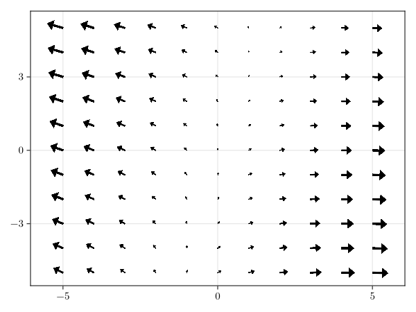

```julia
arrows2d(x, y, ∇h, lengthscale=0.04)
```

Nå skal vi bruke denne teknikken til å plotte konturlinjer og gradientvektorer for funksjonen gitt ved Ligning 1.1. Med noen justeringer fra eksempelet over, kan vi gjøre slik:

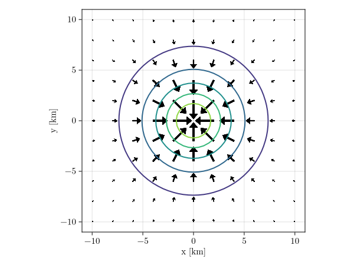

```julia
using CairoMakie
using ForwardDiff: gradient

h0 = 2.277 # km
R = 4 # km

function h(point)
    x = point[1]
    y = point[2]
    return h0 / (1 + (x^2 + y^2) / R^2)
end

∇h(point) = gradient(h, point)

nx = 41
ny = 41
x = LinRange(-10, 10, nx)
y = LinRange(-10, 10, ny)
points = Point2f.(x, y') # matrise med punkter
z = h.(points)


x_gradient = LinRange(-10, 10, 11)
y_gradient = LinRange(-10, 10, 11)


fig = Figure()
ax = Axis(fig[1, 1], xlabel="x [km]", ylabel="y [km]", aspect=DataAspect())
arrows2d!(ax, x_gradient, y_gradient, ∇h, lengthscale=5)
contour!(ax, x, y, z, linewidth=2)
fig
```

Her legger vi merke til at vektorene står vinkelrett på konturlinjene, akkurat som vi skulle ha forventet. For å sikre at dette ser riktig ut, er det viktig å bruke `DataAspect()` på aksen, slik at aksene ikke blir forskjellige skalerte.

Ettersom `ForwardDiff.gradient` tar inn funksjoner som tar inn et punkt, definerer vi `h` som en funksjon som tar inn et punkt. For å beregne matrisen med z-verdier, bruker vi `h.(points)`, altså regner vi ut $h$ elementvis for alle punktene i matrisen (et element er et punkt).

## 3.6 Plotting av strømlinjer

I kapittel 4 møter vi strømfunksjonen $\psi$. Kjenner vi uttrykket for denne er det lett å plotte strømlinjene. Siden strømfunksjonen er konstant langs en strømlinje vil strømlinjene være konturlinjer for skalarfeltet $\psi$. Vi kan derfor definere et grid med en x- og en y-vektor som tidligere, regne ut diskrete verdier av strømfunksjonen for hvert punkt i gridet, og til slutt bruke contour-funksjonen for å plotte strømlinjene, på samme måte som vi plottet isobarene til trykkfeltet i seksjon 3.4 Plotting av konturlinjer.

**Note**

Noen ganger ønsker vi å plotte strømlinjer og ekviskalarflater i samme plott. I så fall er det et viktig poeng at de kurvefamiliene står vinkelrett på hverandre. Dette oppnås ved å kreve at enhetene langs begge aksene er like, derfor bruker vi `DataAspect()` på aksen.

## 3.7 Oppgaver

Oppgavene som står i boka anbefales og kan gjøres uansett om man bruker Matlab, Python, eller Julia.